# Single Cell Sequencing Analysis

# PCA analysis

1. in order to have equally weighted genes in PCA analysis they need to be normalized and zero centered (z-score)
2. run PCA analysis -> PC-1 is the line which provides the largest SD between the data
3. Elbow plot -> showing the standard deviation for each PC
4. Dim Plot -> regular PCA plot without highlighting a feature
5. Feature Plot -> PCA plot with a featuer of interest highlighted -> ex. perhaps you want to know the T-cell population

```r
pbmc3k <- ScaleData(pbmc3k)
pbmc3k <- RunPCA(pbmc3k)
```

```
PC_ 1
Positive:  CST3, TYROBP, LST1, AIF1, FTL, LYZ, FTH1, FCN1, S100A9, TYMP
       FCER1G, CFD, LGALS1, S100A8, LGALS2, CTSS, SERPINA1, IFITM3, SPI1, PSAP
       CFP, IFI30, SAT1, COTL1, S100A11, NPC2, LGALS3, GSTP1, PYCARD, NCF2
Negative:  MALAT1, LTB, IL32, IL7R, CD2, ACAP1, STK17A, CTSW, CD247, GIMAP5
       AQP3, CCL5, TRAF3IP3, MAL, GZMA, CST7, ITM2A, MYC, HOPX, BEX2
       GIMAP7, LDLRAP1, GZMK, ETS1, ZAP70, TNFAIP8, RIC3, LYAR, SAMD3, RORA
PC_ 2
Positive:  CD79A, MS4A1, TCL1A, HLA-DQA1, HLA-DRA, HLA-DQB1, LINC00926, CD79B, HLA-DRB1, CD74
       HLA-DPB1, HLA-DMA, HLA-DQA2, HLA-DRB5, HLA-DPA1, HLA-DMB, HVCN1, FCRLA, LTB, KIAA0125
       P2RX5, BLNK, IRF8, IGLL5, SWAP70, ARHGAP24, SMIM14, PPP1R14A, C16orf74, RP11-428G5.5
Negative:  NKG7, PRF1, CST7, GZMA, GZMB, FGFBP2, CTSW, GNLY, GZMH, SPON2
       CCL4, FCGR3A, CCL5, CD247, XCL2, CLIC3, AKR1C3, SRGN, HOPX, TTC38
       CTSC, S100A4, ANXA1, IL32, IGFBP7, ID2, ACTB, XCL1, APOBEC3G, SAMD3
PC_ 3
Positive:  HLA-DQA1, CD79A, HLA-DQB1, CD79B, HLA-DPB1, HLA-DPA1, CD74, MS4A1, HLA-DRB1, HLA-DRA
       HLA-DRB5, HLA-DQA2, TCL1A, LINC00926, HLA-DMB, HLA-DMA, HVCN1, FCRLA, TMSB10, IRF8
       BLNK, SMIM14, PLD4, KIAA0125, MALAT1, P2RX5, IGLL5, SWAP70, LAT2, IGJ
Negative:  PPBP, PF4, SDPR, SPARC, GNG11, NRGN, GP9, RGS18, TUBB1, HIST1H2AC
       CLU, AP001189.4, ITGA2B, CD9, TMEM40, PTCRA, CA2, ACRBP, MMD, TREML1
       NGFRAP1, F13A1, SEPT5, RUFY1, TSC22D1, MPP1, CMTM5, MYL9, RP11-367G6.3, GP1BA
PC_ 4
Positive:  HLA-DQA1, CD79A, CD79B, HLA-DQB1, MS4A1, CD74, HLA-DPB1, HLA-DRB1, HLA-DQA2, HLA-DPA1
       TCL1A, HLA-DRA, HIST1H2AC, LINC00926, HLA-DRB5, PF4, SDPR, PPBP, GNG11, SPARC
       GP9, PTCRA, CA2, AP001189.4, HLA-DMA, CD9, NRGN, RGS18, HLA-DMB, TUBB1
Negative:  VIM, IL7R, S100A6, S100A8, S100A4, IL32, S100A9, GIMAP7, TMSB10, S100A10
       MAL, CD14, LGALS2, FYB, CD2, AQP3, RBP7, GIMAP4, FCN1, ANXA1
       S100A12, LYZ, S100A11, MS4A6A, FOLR3, GIMAP5, TMSB4X, AIF1, TRABD2A, IL8
PC_ 5
Positive:  LTB, VIM, IL7R, AQP3, PPA1, LDHA, MAL, KIAA0101, TYMS, CD2
       HN1, TUBA1B, CYTIP, CORO1B, ANXA5, TRADD, PTGES3, COTL1, FYB, IL32
       ZWINT, PRDX1, ITM2A, GDI2, GPR183, RRM2, ABRACL, TNFAIP8, ATP5C1, HMGA1
Negative:  GZMB, FGFBP2, NKG7, GNLY, CST7, CCL4, PRF1, SPON2, GZMA, GZMH
       XCL2, CLIC3, CTSW, CCL5, TTC38, AKR1C3, IGFBP7, XCL1, S100A8, CCL3
       TYROBP, HOPX, CD160, S100A9, LGALS2, S100A12, HAVCR2, PTGDR, RBP7, CD14
```

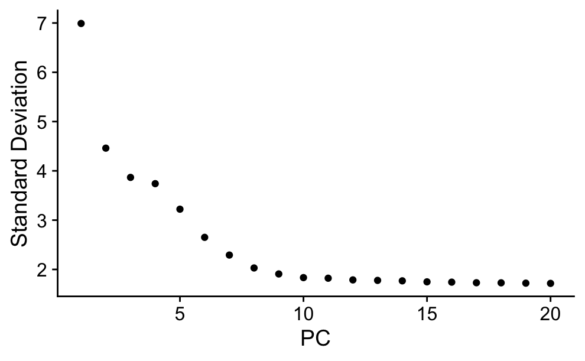

```r
ElbowPlot(pbmc3k, ndims=20)
```

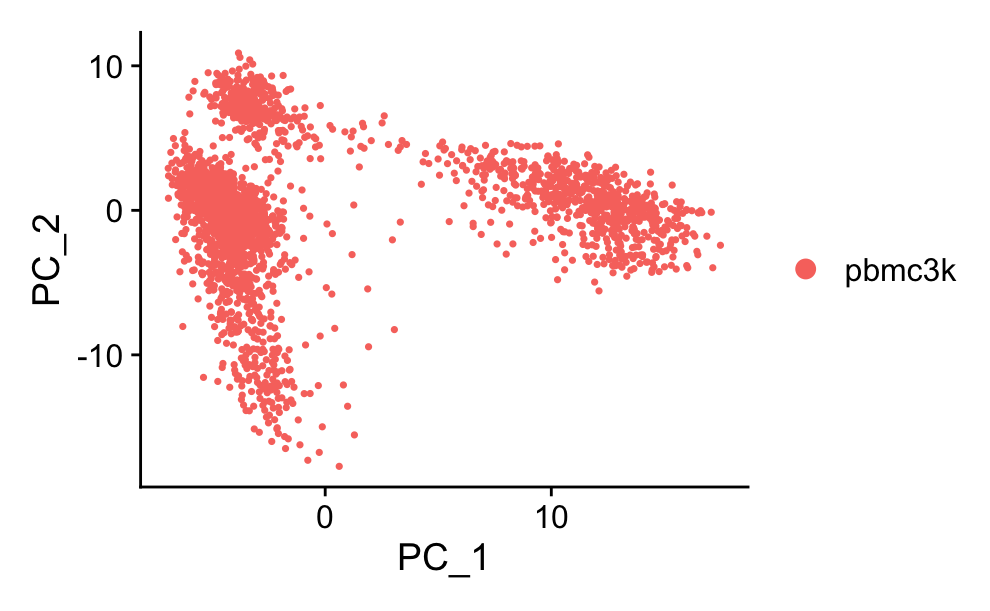

```r
DimPlot(pbmc3k)
```

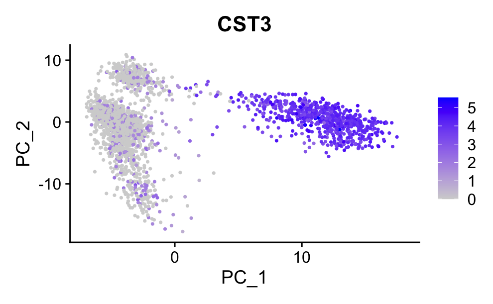

```r
FeaturePlot(pbmc3k, feature='CST3')
```

# non-linear dimensional reduction

UMAP is considered better than t-SNE but feel free to utilize either: -> here I use UMAP

1. UMAP -> find the ‘elbow’ on elbow plot (in our case this is around 10) -> take just those 10 dimensions and reduce them into 2D space
2. DimPlot -> simply plot the UMAP on a scatter plot
3. FeaturePlot -> simply plot the UMAP on a scatter plot with features

```r
pbmc3k <- RunUMAP(pbmc3k, dims=1:10)
```

```
Using method 'umap'
```

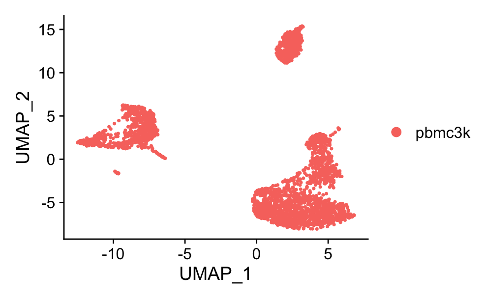

```r
DimPlot(pbmc3k)
```

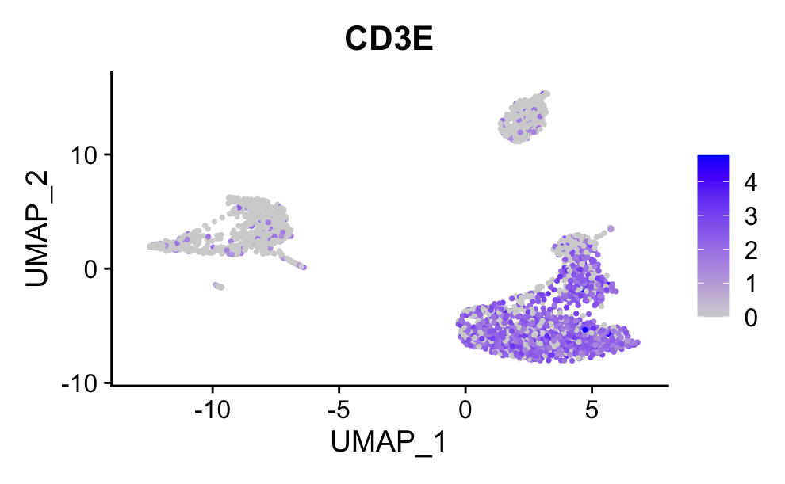

```r
FeaturePlot(pbmc3k, features = 'CD3E')
```

# Clustering

1. findNeighbours -> uses PCA plot to find Neighbours in the graph
2. FindClusters -> assigns clusters based on the resolutaion metric
3. findMarkers -> find the markers that define a cluster -> you can then use a FeaturePlot to highlight

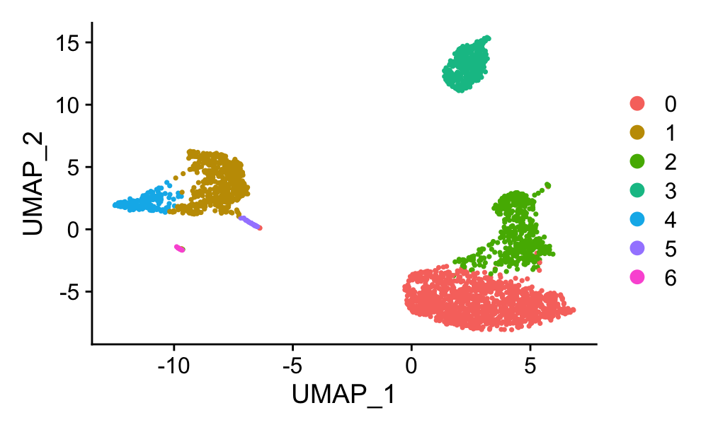